# Regression Model Project

Naqeeb Asif

23 February 2018

# Synopsis

In this experiment mtcars data is explored. First the relationship between miles per gallon and transmission type is examined. It is found out that the there exist a relationship between two . But after adding other variables the transmission type becomes less significant and imapacts the miles per gallon less.

# Loading the data

In this section the data is loaded.

```r
data("mtcars")
head(mtcars)
```

```
##                    mpg cyl disp  hp drat    wt  qsec vs am gear carb
## Mazda RX4         21.0   6  160 110 3.90 2.620 16.46  0  1    4    4
## Mazda RX4 Wag     21.0   6  160 110 3.90 2.875 17.02  0  1    4    4
## Datsun 710        22.8   4  108  93 3.85 2.320 18.61  1  1    4    1
## Hornet 4 Drive    21.4   6  258 110 3.08 3.215 19.44  1  0    3    1
## Hornet Sportabout 18.7   8  360 175 3.15 3.440 17.02  0  0    3    2
## Valiant           18.1   6  225 105 2.76 3.460 20.22  1  0    3    1
```

# Data Processing

In this section the exploratoty analysis is performed on the data.

## Summary of the data

Lets look at the structure and summary of the data.

```r
print("Structure:")
```

```
## [1] "Structure:"
```

```r
str(mtcars)
```

```
## 'data.frame':    32 obs. of  11 variables:
##  $ mpg : num  21 21 22.8 21.4 18.7 18.1 14.3 24.4 22.8 19.2 ...
##  $ cyl : num  6 6 4 6 8 6 8 4 4 6 ...
##  $ disp: num  160 160 108 258 360 ...
##  $ hp  : num  110 110 93 110 175 105 245 62 95 123 ...
##  $ drat: num  3.9 3.9 3.85 3.08 3.15 2.76 3.21 3.69 3.92 3.92 ...
##  $ wt  : num  2.62 2.88 2.32 3.21 3.44 ...
##  $ qsec: num  16.5 17 18.6 19.4 17 ...
##  $ vs  : num  0 0 1 1 0 1 0 1 1 1 ...
##  $ am  : num  1 1 1 0 0 0 0 0 0 0 ...
##  $ gear: num  4 4 4 3 3 3 3 4 4 4 ...
##  $ carb: num  4 4 1 1 2 1 4 2 2 4 ...
```

```r
print("---------------------------------------------------------------")
```

```
## [1] "---------------------------------------------------------------"
```

```r
print("Summary:")
```

```
## [1] "Summary:"
```

```r
summary(mtcars)
```

```
##       mpg             cyl             disp             hp
##  Min.   :10.40   Min.   :4.000   Min.   : 71.1   Min.   : 52.0
##  1st Qu.:15.43   1st Qu.:4.000   1st Qu.:120.8   1st Qu.: 96.5
##  Median :19.20   Median :6.000   Median :196.3   Median :123.0
##  Mean   :20.09   Mean   :6.188   Mean   :230.7   Mean   :146.7
##  3rd Qu.:22.80   3rd Qu.:8.000   3rd Qu.:326.0   3rd Qu.:180.0
##  Max.   :33.90   Max.   :8.000   Max.   :472.0   Max.   :335.0
##       drat             wt             qsec             vs
##  Min.   :2.760   Min.   :1.513   Min.   :14.50   Min.   :0.0000
##  1st Qu.:3.080   1st Qu.:2.581   1st Qu.:16.89   1st Qu.:0.0000
##  Median :3.695   Median :3.325   Median :17.71   Median :0.0000
##  Mean   :3.597   Mean   :3.217   Mean   :17.85   Mean   :0.4375
##  3rd Qu.:3.920   3rd Qu.:3.610   3rd Qu.:18.90   3rd Qu.:1.0000
##  Max.   :4.930   Max.   :5.424   Max.   :22.90   Max.   :1.0000
##        am              gear            carb
##  Min.   :0.0000   Min.   :3.000   Min.   :1.000
##  1st Qu.:0.0000   1st Qu.:3.000   1st Qu.:2.000
##  Median :0.0000   Median :4.000   Median :2.000
##  Mean   :0.4062   Mean   :3.688   Mean   :2.812
##  3rd Qu.:1.0000   3rd Qu.:4.000   3rd Qu.:4.000
##  Max.   :1.0000   Max.   :5.000   Max.   :8.000
```

## Converting Features to ‘Factor’ type

As we can see from the summary of the data that somes features should not be of numeric type so lets convert those features to ‘factor’.

```r
library(dplyr)

data_mtcars <- mtcars %>% mutate(cyl=factor(cyl),vs=factor(vs,labels = c("V-shape","Straight Line"),levels = c(0,1)),
                  am=factor(am,labels = c("Automatic","Manual"),levels = c(0,1)),
                  gear=factor(gear),carb=factor(carb))
```

# Exploratory Analysis

In this section exploratory analysis is performed on the data.

## Reltionship Between Miles per Gallon and Transmssion Type

```r
library(dplyr)
mData <- data_mtcars %>% select(mpg,am) %>%group_by(am) %>%summarise(mean=mean(mpg))
```

The mean of mpg for automatic transmission type is 17.15 and the mean of mpg for manual transmission is 24.39. The difference between mean for the two transmission types are 7.24. So we can say that manual transission type gives better miles per gallon.

## Correlations

In this section we’ll explore the correlations between different variables. The correlation plot of the data is shown in appendix 3.As correlation can only be found out between numerical variables so original data is used.

```r
cor_mat <- cor(mtcars)
cor_mat[1,]
```

```
##        mpg        cyl       disp         hp       drat         wt
##  1.0000000 -0.8521620 -0.8475514 -0.7761684  0.6811719 -0.8676594
##       qsec         vs         am       gear       carb
##  0.4186840  0.6640389  0.5998324  0.4802848 -0.5509251
```

# Regression Model

Now lets look at regression model between transmission type and miles per gallon

```r
fit1 <- lm(mpg~am,data=data_mtcars)
summary(fit1)
```

```
##
## Call:
## lm(formula = mpg ~ am, data = data_mtcars)
##
## Residuals:
##     Min      1Q  Median      3Q     Max
## -9.3923 -3.0923 -0.2974  3.2439  9.5077
##
## Coefficients:
##             Estimate Std. Error t value Pr(>|t|)
## (Intercept)   17.147      1.125  15.247 1.13e-15 ***
## amManual       7.245      1.764   4.106 0.000285 ***
## ---
## Signif. codes:  0 '***' 0.001 '**' 0.01 '*' 0.05 '.' 0.1 ' ' 1
##
## Residual standard error: 4.902 on 30 degrees of freedom
## Multiple R-squared:  0.3598, Adjusted R-squared:  0.3385
## F-statistic: 16.86 on 1 and 30 DF,  p-value: 0.000285
```

From the above results we can conclude the following:

- p-value for the variable is less than 0.05 so the model is acceptable.
- The coefficient beta0 is equal to the mean of mpg for automatic transmission type.
- The coefficient beta1 is equal to the difference between mean of mpg for two transmission types as explained above.
- The coefficients also give the result that mpg for manual transmission type is larger than that automatic transmission type.
- r-squared is only 0.33 which means only 33% of the variance is covered by the model.

# Better Model

From the above results it can be seen that the model is not a good model .Lets add the four features ,which we found in the exploratory analysis, in the model.

```r
better_fit <- update(fit1,mpg~am+cyl+disp+hp+wt)
anova(fit1,better_fit)
```

```
## Analysis of Variance Table
##
## Model 1: mpg ~ am
## Model 2: mpg ~ am + cyl + disp + hp + wt
##   Res.Df    RSS Df Sum of Sq      F    Pr(>F)
## 1     30 720.90
## 2     25 150.41  5    570.49 18.965 8.637e-08 ***
## ---
## Signif. codes:  0 '***' 0.001 '**' 0.01 '*' 0.05 '.' 0.1 ' ' 1
```

From the above results it can be seen the model performs better than the previous one as the p-value is very close to 0. Now lets look at the summary of the model.

```r
summary(better_fit)
```

```
##
## Call:
## lm(formula = mpg ~ am + cyl + disp + hp + wt, data = data_mtcars)
##
## Residuals:
##     Min      1Q  Median      3Q     Max
## -3.9374 -1.3347 -0.3903  1.1910  5.0757
##
## Coefficients:
##              Estimate Std. Error t value Pr(>|t|)
## (Intercept) 33.864276   2.695416  12.564 2.67e-12 ***
## amManual     1.806099   1.421079   1.271   0.2155
## cyl6        -3.136067   1.469090  -2.135   0.0428 *
## cyl8        -2.717781   2.898149  -0.938   0.3573
## disp         0.004088   0.012767   0.320   0.7515
## hp          -0.032480   0.013983  -2.323   0.0286 *
## wt          -2.738695   1.175978  -2.329   0.0282 *
## ---
## Signif. codes:  0 '***' 0.001 '**' 0.01 '*' 0.05 '.' 0.1 ' ' 1
##
## Residual standard error: 2.453 on 25 degrees of freedom
## Multiple R-squared:  0.8664, Adjusted R-squared:  0.8344
## F-statistic: 27.03 on 6 and 25 DF,  p-value: 8.861e-10
```

As it can be seen from the above results that the above model covers 86.6% variance and it is a better model.

## Residual Plot analysis

The residual plot is plotted in apendex 4 . Following are the results which are obtained from the plots * No relation is found between residuals and fitted values showing that residuals have constant variance. * Normal Q-Q plot indicates the normal distribution of the residuals. * Leverage plot indicates that there are some outliers in the plot causing the leverage in the plot.

# Conclusion

We can conclude that manual transmission type car has more miles per gallon (average of 7) than the automatic transmission type. Moreover when we inculde other features then transmission type has less significant impact on the miles per gallon of the car. The residual obtained after fitting the most correlated features have constant variance and almost normal distribution.

# Appendix

## A.1 BoxPlots between mpg and differnt factor features.

[figure not shown]

```r
library(ggplot2)
library(gridExtra)

g <- ggplot(data = mtcars,aes(y=mpg))
g1 <- g + geom_boxplot(aes(x=cyl,fill=cyl)) + labs(title="Cyl vs mpg") +
      theme(plot.title = element_text(hjust = 0.5))
g2 <- g + geom_boxplot(aes(x=vs,fill=vs)) + labs(title="VS vs mpg") +
      theme(plot.title = element_text(hjust = 0.5))
g3 <- g + geom_boxplot(aes(x=am,fill=am)) + labs(title="am vs mpg") +
      theme(plot.title = element_text(hjust = 0.5))
g4 <- g + geom_boxplot(aes(x=gear,fill=gear)) + labs(title="gear vs mpg") +
      theme(plot.title = element_text(hjust = 0.5))
g5 <- g + geom_boxplot(aes(x=carb,fill=carb)) + labs(title="carb vs mpg") +
      theme(plot.title = element_text(hjust = 0.5))
grid.arrange(g1,g2,g3,g4,g5,ncol=3,top="BoxPlot")
```

## A.2 Scatter Plots between mpg and numerical features

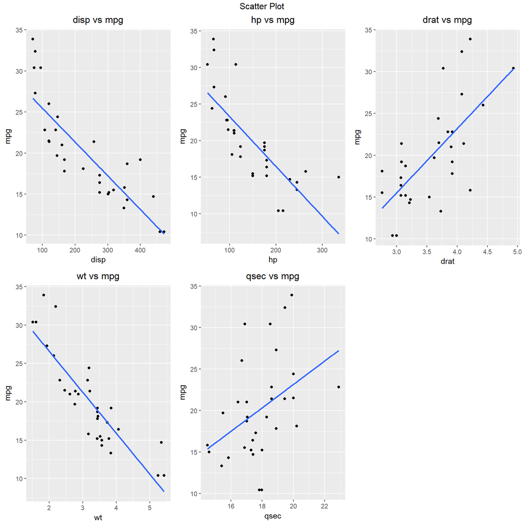

```r
library(ggplot2)
library(gridExtra)

g <- ggplot(data = mtcars,aes(y=mpg))
g1 <- g + geom_point(aes(x=disp)) + labs(title="disp vs mpg") +
      theme(plot.title = element_text(hjust = 0.5)) +
      geom_smooth(method = "lm",se=FALSE,aes(x=disp))

g2 <- g + geom_point(aes(x=hp)) + labs(title="hp vs mpg") +
      theme(plot.title = element_text(hjust = 0.5)) +
      geom_smooth(method = "lm",se=FALSE,aes(x=hp))

g3 <- g + geom_point(aes(x=drat)) + labs(title="drat vs mpg") +
      theme(plot.title = element_text(hjust = 0.5)) +
      geom_smooth(method = "lm",se=FALSE,aes(x=drat))

g4 <- g + geom_point(aes(x=wt)) + labs(title="wt vs mpg") +
      theme(plot.title = element_text(hjust = 0.5)) +
      geom_smooth(method = "lm",se=FALSE,aes(x=wt))

g5 <- g + geom_point(aes(x=qsec)) + labs(title="qsec vs mpg") +
      theme(plot.title = element_text(hjust = 0.5)) +
      geom_smooth(method = "lm",se=FALSE,aes(x=qsec))

grid.arrange(g1,g2,g3,g4,g5,ncol=3,top="Scatter Plot")
```

## A.3 correlation Plot

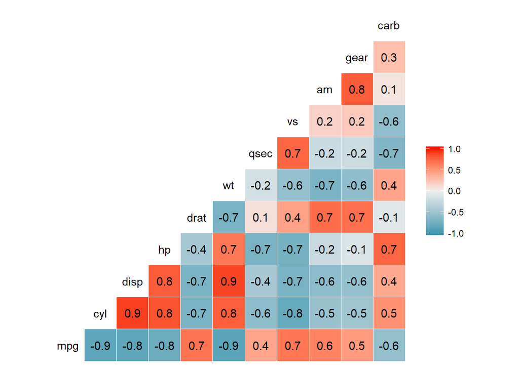

```r
library(GGally)
data(mtcars)
ggcorr(mtcars,label = TRUE)
```

## A.4 Residual Plot

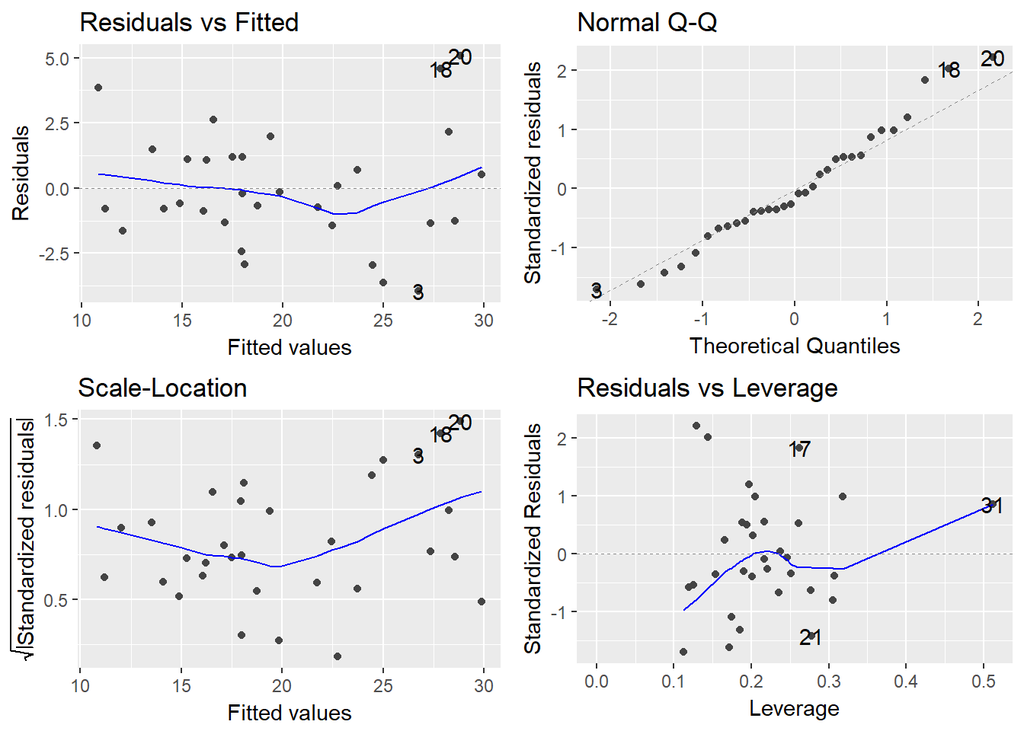

```r
library(ggfortify)
autoplot(better_fit)
```